# Unidirectional_RNN_using_Golve_Q_1

```python
!pip install autocorrect
```

```
     ━━━━━━━━━━━━━━━━━━━━━━━━━━━━━━━━━━━━━━━━ 622.8/622.8 kB 6.5 MB/s eta 0:00:00
  Preparing metadata (setup.py) ... done
```

```python
import pandas as pd
import re
import nltk
from nltk.corpus import stopwords
from nltk.tokenize import word_tokenize
from nltk.stem import WordNetLemmatizer
from autocorrect import Speller
from sklearn.feature_extraction.text import TfidfVectorizer
from sklearn.decomposition import TruncatedSVD
from sklearn.preprocessing import LabelEncoder
from sklearn.model_selection import train_test_split
import matplotlib.pyplot as plt
```

**DATA PREPROCESSING**

Data preprocessing includes:

1. Lowercase the text
2. Remove the url
3. Remove special characters, numbers, and punctuations
4. Remove mention
5. Remove Hashtags
6. remove white extraa space
7. Remove email id
8. Remove username
9. Remove short name
1. slangs handling
1. abbreviations handling
1. Idoms handling
1. Tokenization
1. Stop_words
1. Lemmitization

```python
dp = pd.read_csv('Sentiment_Data.csv',encoding='latin-1')
```

```python
dp.head(25)
```

|  | Tweet | Sentiment |
| --- | --- | --- |
| 0 | @_angelica_toy Happy Anniversary!!!....The Day... | Mild_Pos |
| 1 | @McfarlaneGlenda Happy Anniversary!!!....The D... | Mild_Pos |
| 2 | @thevivafrei @JustinTrudeau Happy Anniversary!... | Mild_Pos |
| 3 | @NChartierET Happy Anniversary!!!....The Day t... | Mild_Pos |
| 4 | @tabithapeters05 Happy Anniversary!!!....The D... | Mild_Pos |
| 5 | @JusticeStyle Happy Anniversary!!!....The Day ... | Mild_Pos |
| 6 | @Praiset22112963 @Emergencies_Act @ikwilson Ha... | Mild_Pos |
| 7 | @parnel1123 @RealAndyLeeShow Happy Anniversary... | Mild_Pos |
| 8 | Freedom Convoy as InkBlot Test https://t.co/au... | Strong_Pos |
| 9 | @WSOnlineNews @DavidKrayden Happy Anniversary!... | Mild_Pos |
| 10 | @TammyNiemi @Emergencies_Act Happy Anniversary... | Mild_Pos |
| 11 | @westglassart @Emergencies_Act Happy Anniversa... | Mild_Pos |
| 12 | @James_Mc666 Happy Anniversary!!!....The Day t... | Mild_Pos |
| 13 | @mark_slapinski Well itâs pretty easy to see... | Strong_Pos |
| 14 | @Bird5Ca Happy Anniversary!!!....The Day the F... | Mild_Pos |
| 15 | @HenriAGS Happy Anniversary!!!....The Day the ... | Mild_Pos |
| 16 | @ShaunRickard67 @brianlilley Happy Anniversary... | Mild_Pos |
| 17 | @canadiancynic Happy Anniversary!!!....The Day... | Mild_Pos |
| 18 | @lak_ted Happy Anniversary!!!....The Day the F... | Mild_Pos |
| 19 | @DavidKrayden Happy Anniversary!!!....The Day ... | Mild_Pos |
| 20 | @brianlilley Happy Anniversary!!!....The Day t... | Mild_Pos |
| 21 | @TheTorontoSun Happy Anniversary!!!....The Day... | Mild_Pos |
| 22 | @TheBeaverton Happy Anniversary!!!....The Day ... | Mild_Pos |
| 23 | @JustinTrudeau You Belong In Jail.\n#VaccineMa... | Neutral |
| 24 | @1MikeMorris Happy Anniversary!!!....The Day t... | Mild_Pos |

```python
dp.Sentiment.value_counts()
```

```
Strong_Pos    233700
Neutral        77016
Mild_Pos       64004
Strong_Neg     42556
Mild_Neg       34056
Name: Sentiment, dtype: int64
```

```python
# Download NLTK resources
nltk.download('punkt')
nltk.download('stopwords')
nltk.download('wordnet')
```

```
True
```

```python
def preprocess_text(text):
  if isinstance(text, str):
    # Lowercase the text
    text = text.lower()

    # Removing URLs
    text = re.sub(r'http\S+', '', text)

    # Removing special characters, numbers, and punctuations
    text = re.sub(r'[^a-z#@]', ' ', text)

    text = re.sub(r'@[A-Za-z0-9]+', '', text)   # Removeing mentions

    text = re.sub(r'#', '', text)  # Removeing hashtags

    text = re.sub(r'\s+', ' ', text).strip()  # Removing extra whitespaces

    text = re.sub(r'\b[\w\-.]+?@\w+?\.\w{2,4}\b', '', text)  # Removing email ids

    text = re.sub(r'@\w+', '', text) # Removing usernames

    text = re.sub(r'\b\w{1,2}\b', '', text) # Removing short words


    return text
```

```python
dp['lemmatized_tweet'] = dp['Tweet'].apply(preprocess_text)
```

```python
dp.head(5)
```

|  | Tweet | Sentiment | lemmatized_tweet |
| --- | --- | --- | --- |
| 0 | @_angelica_toy Happy Anniversary!!!....The Day... | Mild_Pos | @ angelica toy happy anniversary the day the f... |
| 1 | @McfarlaneGlenda Happy Anniversary!!!....The D... | Mild_Pos | happy anniversary the day the freedumb died t... |
| 2 | @thevivafrei @JustinTrudeau Happy Anniversary!... | Mild_Pos | happy anniversary the day the freedumb died t... |
| 3 | @NChartierET Happy Anniversary!!!....The Day t... | Mild_Pos | happy anniversary the day the freedumb died t... |
| 4 | @tabithapeters05 Happy Anniversary!!!....The D... | Mild_Pos | happy anniversary the day the freedumb died t... |

```python
def slang(text):

    slang_dict = {
    "lol": "laugh out loud",
    "brb": "be right back",
    "btw": "by the way",
    "idk": "I don't know",
    "omg": "oh my god",
    "tbh": "to be honest",
    "bff": "best friends forever",
    "smh": "shake my head",
    "imo": "in my opinion",
    "fyi": "for your information",
    "irl": "in real life",
    "rofl": "rolling on the floor laughing",
    "gtg": "got to go",
    "tyt": "take your time",
    "af": "as fuck",
    "ftw": "for the win",
    "hmu": "hit me up",
    "tb": "throwback",
    "tmi": "too much information",
    "omw": "on my way",
    "np": "no problem",
    "smh": "shaking my head",
    "wyd": "what are you doing",
    "wya": "where you at",
    "nvm": "never mind",
    "gg": "good game",
    "jsyk": "just so you know",
    "imo": "in my opinion",
    "hmu": "hit me up",
    "afk": "away from keyboard",
    "jk": "just kidding",
    "dm": "direct message",
    "rt": "retweet",
    "dm": "direct message",
    "yolo": "you only live once",
    "fomo": "fear of missing out",
    "tfw": "that feeling when",
    "ootd": "outfit of the day",
    "fml": "fuck my life",
    "smfh": "shaking my fucking head",
    "tbt": "throwback Thursday",
    "ff": "follow Friday",
    "btfo": "blown the fuck out",
    "wcw": "woman crush Wednesday",
    "mcm": "man crush Monday",
    "bae": "before anyone else"
}

    if text is not None:
        return ' '.join(slang_dict.get(word, word) for word in text.split())
    else:
        return text
```

```python
dp['lemmatized_tweet'] = dp['lemmatized_tweet'].apply(slang)
```

```python
def abbreviations(text):
    abbreviation_dict = {
        "u": "you",
        "r": "are",
        "2": "to",
        "gr8": "great",
        "bc": "because",
        "w/o": "without",
        "msg": "message",
        "pls": "please",
        "thx": "thanks",
        "wtf": "what the f***",
        "omg": "oh my god",
        "fyi": "for your information",
        "imo": "in my opinion",
        "idk": "I don't know",
        "lol": "laughing out loud",
        "btw": "by the way",
        "omw": "on my way",
        "hmu": "hit me up",
        "tbh": "to be honest",
        "tmi": "too much information",
        "fyi": "for your information",
        "smh": "shaking my head",
        "imho": "in my humble opinion",
        "fomo": "fear of missing out",
        "af": "as f***",
        "bff": "best friends forever",
        "ftw": "for the win",
        "gtg": "got to go",
        "hmu": "hit me up",
        "irl": "in real life",
        "lmao": "laughing my ass off",
        "rofl": "rolling on the floor laughing",
        "wcw": "woman crush Wednesday",
        "mcm": "man crush Monday",
        "smh": "shaking my head",
        "wyd": "what you doing",
        "yolo": "you only live once",
        "tbt": "throwback Thursday",
        "icymi": "in case you missed it",
        "brb": "be right back",
        "smdh": "shaking my damn head",
        "gtfo": "get the f*** out",
        "idc": "I don't care",
        "imo": "in my opinion",
        "idk": "I don't know"
    }
    if text is not None:
        return ' '.join(abbreviation_dict.get(word, word) for word in text.split())
    else:
        return text
```

```python
dp['lemmatized_tweet'] = dp['lemmatized_tweet'].apply(abbreviations)
```

```python
def idioms(text):
    idiom_dict = {
        "wait to": "excited about",
        "can't wait": "excited about",
        "rain on my parade": "spoil my plans",
        "hit the hay": "go to bed",
        "cost an arm and a leg": "very expensive",
        "raining cats and dogs": "heavy rain",
        "under the weather": "not feeling well",
        "piece of cake": "very easy",
        "burn the midnight oil": "work late into the night",
        "break a leg": "good luck",
        "spill the beans": "reveal a secret",
        "in hot water": "in trouble",
        "jump on the bandwagon": "join a popular trend",
        "kick the bucket": "pass away",
        "needle in a haystack": "hard to find",
        "out of the blue": "unexpectedly",
        "cold feet": "nervous",
        "once in a blue moon": "rarely",
        "barking up the wrong tree": "mistaken",
        "elephant in the room": "obvious issue",
        "back to the drawing board": "start over",
        "break the ice": "relieve tension",
        "by the skin of your teeth": "barely succeed",
        "call it a day": "end work",
        "caught red-handed": "caught in the act",
        "cry over spilled milk": "regret something already done"
        # Add more idioms and their meanings
    }
    if text is not None:
        return ' '.join(idiom_dict.get(word, word) for word in text.split())
    else:
        return text
```

```python
dp['lemmatized_tweet'] = dp['lemmatized_tweet'].apply(idioms)
```

```python
def tokenization(text):
    if text is not None:
        return word_tokenize(text)
    else:
        return []
```

```python
dp['tokenized_tweet'] = dp['lemmatized_tweet'].apply(tokenization)
```

```python
def remove_stopwords(tokens):
    if tokens is not None:
        return [word for word in tokens if word not in stopwords.words('english')]
    else:
        return []
```

```python
dp['tokenized_tweet'] = dp['tokenized_tweet'].apply(remove_stopwords)
```

```python
def lemmatization(tokens):
    if tokens is not None:
        lemmatizer = WordNetLemmatizer()
        return ' '.join(lemmatizer.lemmatize(token) for token in tokens)
    else:
        return ''
```

```python
dp['lemmatized_tweet'] = dp['tokenized_tweet'].apply(lemmatization)
```

```python
dp.to_csv('dp_preprocessed.csv', index=False)
```

```python
dp.head(5)
```

|  | Tweet | Sentiment | lemmatized_tweet | tokenized_tweet |
| --- | --- | --- | --- | --- |
| 0 | @_angelica_toy Happy Anniversary!!!....The Day... | Mild_Pos | @ angelica toy happy anniversary day freedumb ... | [@, angelica, toy, happy, anniversary, day, fr... |
| 1 | @McfarlaneGlenda Happy Anniversary!!!....The D... | Mild_Pos | happy anniversary day freedumb died tune mclea... | [happy, anniversary, day, freedumb, died, tune... |
| 2 | @thevivafrei @JustinTrudeau Happy Anniversary!... | Mild_Pos | happy anniversary day freedumb died tune mclea... | [happy, anniversary, day, freedumb, died, tune... |
| 3 | @NChartierET Happy Anniversary!!!....The Day t... | Mild_Pos | happy anniversary day freedumb died tune mclea... | [happy, anniversary, day, freedumb, died, tune... |
| 4 | @tabithapeters05 Happy Anniversary!!!....The D... | Mild_Pos | happy anniversary day freedumb died tune mclea... | [happy, anniversary, day, freedumb, died, tune... |

**Class separability**

```python
from sklearn.model_selection import train_test_split


X = dp['lemmatized_tweet']
y = dp['Sentiment']

X_train, X_test, y_train, y_test = train_test_split(X, y, test_size=0.2, random_state=42)
```

```python
X_test.shape
```

```
(90267,)
```

```python
# Applying preprocessing on both training and testing set

def preprocess_data(X):
    X = X.apply(preprocess_text)
    X = X.apply(slang)
    X = X.apply(abbreviations)
    X = X.apply(idioms)
    X = X.apply(tokenization)
    X = X.apply(remove_stopwords)
    X = X.apply(lemmatization)
    return X

X_train_processed = preprocess_data(X_train)
X_test_processed = preprocess_data(X_test)
```

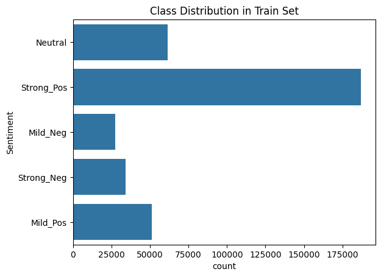

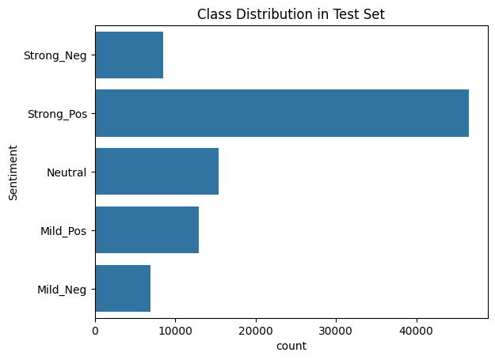

```python
import seaborn as sns
import matplotlib.pyplot as plt

# Checking class distribution in train set
sns.countplot(y_train)
plt.title('Class Distribution in Train Set')
plt.show()

# Checking class distribution in test set
sns.countplot(y_test)
plt.title('Class Distribution in Test Set')
plt.show()
```

**MODEL IMPLEMENTATION**

```python
import numpy as np
import pandas as pd
from sklearn.model_selection import train_test_split
from keras.preprocessing.text import Tokenizer
from keras.preprocessing.sequence import pad_sequences
from keras.utils import to_categorical
from keras.models import Sequential
from keras.layers import Embedding, LSTM, Dense , Dropout
```

```python
# joined sentiment classes
dp['Sentiment'] = dp['Sentiment'].replace({'Strong_Pos': 'Positive', 'Mild_Pos': 'Positive',
                                               'Strong_Neg': 'Negative', 'Mild_Neg': 'Negative'})
```

```python
# select input and target column
X = dp['lemmatized_tweet']
y = dp['Sentiment']
```

```python
# Tokenizing text
tokenizer = Tokenizer()
tokenizer.fit_on_texts(X)
X_sequences = tokenizer.texts_to_sequences(X)
```

```python
# Pad sequences
max_sequence_length = max([len(seq) for seq in X_sequences])
X_padded = pad_sequences(X_sequences, maxlen=max_sequence_length)
```

```python
# Converting sentiment labels into categorical values
sentiment_mapping = {'Positive': 0, 'Neutral': 1, 'Negative': 2}
y_categorical = [sentiment_mapping[sentiment] for sentiment in y]
y_categorical = to_categorical(y_categorical)
```

```python
# Train-test splitting the data
X_train, X_test, y_train, y_test = train_test_split(X_padded, y_categorical, test_size=0.2, random_state=42)
```

```python
# Load GloVe embeddings
embeddings_index = {}
embedding_dim = 100  # Adjust dimension according to the GloVe embedding file you're using
with open('glove.6B.100d.txt', encoding='utf-8') as f:  # Replace with your GloVe embedding file
    for line in f:
        values = line.split()
        word = values[0]
        coefs = np.asarray(values[1:], dtype='float32')
        embeddings_index[word] = coefs
```

```python
# Create embedding matrix
word_index = tokenizer.word_index
num_words = len(word_index) + 1
embedding_matrix = np.zeros((num_words, embedding_dim))
for word, i in word_index.items():
    if i < num_words:
        embedding_vector = embeddings_index.get(word)
        if embedding_vector is not None:
            embedding_matrix[i] = embedding_vector
```

```python
model = Sequential()
model.add(Embedding(num_words, embedding_dim, weights=[embedding_matrix], input_length=max_sequence_length, trainable=False))
model.add(LSTM(128, return_sequences=True))  #first LSTM layer
model.add(LSTM(64))  # Second LSTM layer
model.add(Dense(64, activation='relu'))  # Dense layer with ReLU activation
model.add(Dropout(0.5))  # Dropout layer to prevent overfitting
model.add(Dense(3, activation='softmax'))
```

```python
# Compile=ing the  model
model.compile(optimizer='adam', loss='categorical_crossentropy', metrics=['accuracy'])
```

```python
# Training the model
model.fit(X_train, y_train, epochs=5, batch_size=64, validation_data=(X_test, y_test))
```

```
<keras.src.callbacks.History at 0x7d66546fdc90>
```

**MODEL EVOLUTION ON TRAINING DATA**

```python
from sklearn.metrics import accuracy_score, roc_auc_score, roc_curve,f1_score, confusion_matrix
```

```python
#Making  predictions on training data
train_pred = model.predict(X_train)
train_pred_lab = np.argmax(train_pred, axis=1)
```

```python
train_pred_lab.shape
```

```
(361065,)
```

```python
# Convert one-hot encoded y_train back to categorical labels
y_train_lab = np.argmax(y_train, axis=1)
```

```python
y_train_lab.shape
```

```
(361065,)
```

```python
# Calculate accuracy
training_data_accuracy = accuracy_score(np.argmax(y_train, axis=1), train_pred_lab)

# Calculate AUC
training_data_auc = roc_auc_score(y_train, train_pred, multi_class='ovr')

# Calculate confusion matrix
training_data_conf_matrix = confusion_matrix(y_train_lab, train_pred_lab)
```

```python
# Calculate F1 score for positive and negative classes
training_data_f1_positive = f1_score(np.argmax(y_train, axis=1), train_pred_lab, labels=[0], average='macro')
training_data_f1_negative = f1_score(np.argmax(y_train, axis=1), train_pred_lab, labels=[2], average='macro')
```

```python
print('Training Data Check:')
print("Training Accuracy:", training_data_accuracy)
print("Training AUC:", training_data_auc)
print("Training Confusion Matrix:")
print(training_data_conf_matrix)
print("Training F1 Score (Positive):", training_data_f1_positive)
print("Training F1 Score (Negative):", training_data_f1_negative)
```

```
Training Data Check:
Training Accuracy: 0.8626978521872793
Training AUC: 0.9398722540143675
Training Confusion Matrix:
[[230199   2750   5287]
 [ 18669  35638   7283]
 [ 13492   2094  45653]]
Training F1 Score (Positive): 0.91969971793622
Training F1 Score (Negative): 0.7643099897875476
```

**PLOTTING CONFUSION MATRIX AND ROC-AUC CURVE OF TRAINING DATA**

```python
import matplotlib.pyplot as plt
from sklearn.metrics import roc_curve, auc, ConfusionMatrixDisplay
```

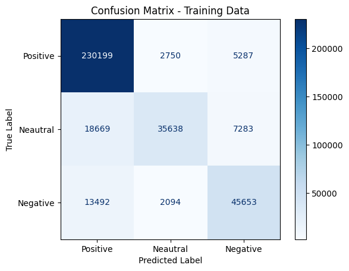

```python
# Plot Confusion Matrix
plt.figure(figsize=(8, 6))
ConfusionMatrixDisplay(confusion_matrix=training_data_conf_matrix,
                       display_labels=['Positive', 'Neautral', 'Negative']).plot(cmap='Blues')
plt.title('Confusion Matrix - Training Data')
plt.xlabel('Predicted Label')
plt.ylabel('True Label')
plt.grid(False)
plt.show()
```

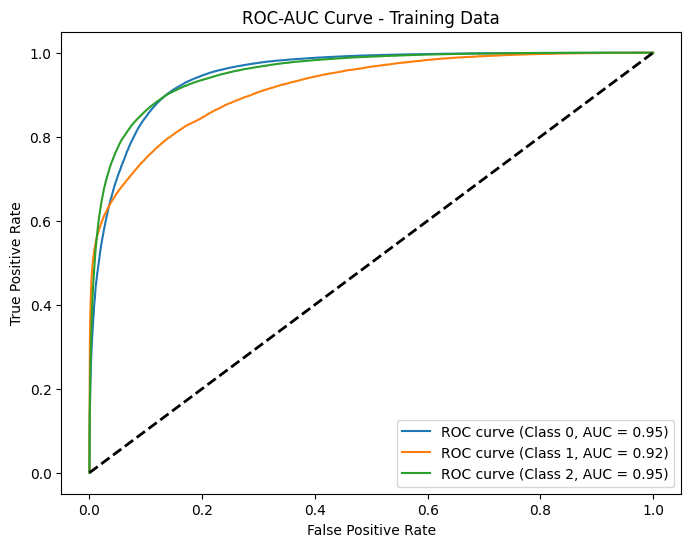

```python
import matplotlib.pyplot as plt
from sklearn.metrics import roc_curve, auc

plt.figure(figsize=(8, 6))
fpr = dict()
tpr = dict()
roc_auc = dict()
num_classes = 3  # Assuming you have 3 classes
for i in range(num_classes):
    fpr[i], tpr[i], _ = roc_curve(y_train[:, i], train_pred[:, i])
    roc_auc[i] = auc(fpr[i], tpr[i])
    plt.plot(fpr[i], tpr[i], label=f'ROC curve (Class {i}, AUC = {roc_auc[i]:0.2f})')

plt.plot([0, 1], [0, 1], 'k--', lw=2)
plt.xlabel('False Positive Rate')
plt.ylabel('True Positive Rate')
plt.title('ROC-AUC Curve - Training Data')
plt.legend(loc="lower right")
plt.show()
```

**MODEL EVOLUTION ON TESTING DATA**

```python
# Test predictions
test_pred = model.predict(X_test)
test_pred_lab = np.argmax(test_pred, axis=1)
```

```python
test_pred_lab.shape
```

```
(90267,)
```

```python
# Convert one-hot encoded y_train back to categorical labels
y_test_lab = np.argmax(y_test, axis=1)
```

```python
y_test_lab.shape
```

```
(90267,)
```

```python
# Calculate accuracy
testing_data_accuracy = accuracy_score(np.argmax(y_test, axis=1), test_pred_lab)

# Calculate AUC
testing_data_auc = roc_auc_score(y_test, test_pred, multi_class='ovr')

# Calculate confusion matrix
testing_data_conf_matrix = confusion_matrix(y_test_lab, test_pred_lab)
```

```python
# Calculate F1 score for positive and negative classes
testing_data_f1_positive = f1_score(np.argmax(y_test, axis=1), test_pred_lab, labels=[0], average='macro')
testing_data_f1_negative = f1_score(np.argmax(y_test, axis=1), test_pred_lab, labels=[2], average='macro')
```

```python
print('Testing Data Check:')
print("Testing Accuracy:", testing_data_accuracy)
print("Testing AUC:", testing_data_auc)
print("Testing Confusion Matrix:")
print(testing_data_conf_matrix)
print("Testing F1 Score (Positive):", testing_data_f1_positive)
print("Testing F1 Score (Negative):", testing_data_f1_negative)
```

```
Testing Data Check:
Testing Accuracy: 0.836318920535744
Testing AUC: 0.9124081612202396
Testing Confusion Matrix:
[[56524  1089  1855]
 [ 5169  8277  1980]
 [ 3954   728 10691]]
Testing F1 Score (Positive): 0.903552731487032
Testing F1 Score (Negative): 0.7151409746145355
```

**PLOTTING CONFUSION MATRIX AND ROC-AUC CURVE OF TESTING DATA**

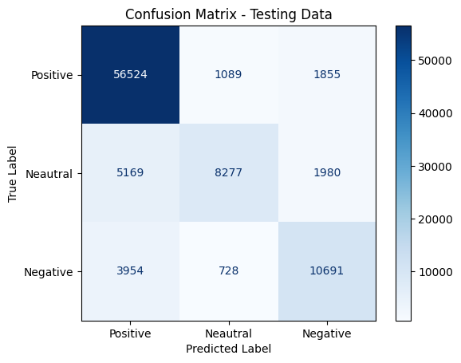

```python
# Plot Confusion Matrix
plt.figure(figsize=(8, 6))
ConfusionMatrixDisplay(confusion_matrix=testing_data_conf_matrix,
                       display_labels=['Positive', 'Neautral', 'Negative']).plot(cmap='Blues')
plt.title('Confusion Matrix - Testing Data')
plt.xlabel('Predicted Label')
plt.ylabel('True Label')
plt.grid(False)
plt.show()
```

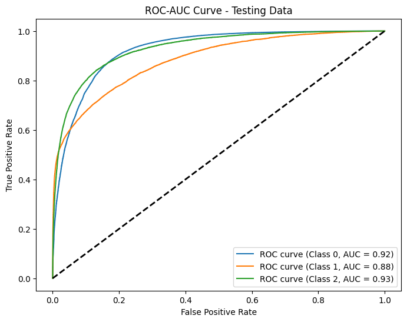

```python
import matplotlib.pyplot as plt
from sklearn.metrics import roc_curve, auc

plt.figure(figsize=(8, 6))
fpr = dict()
tpr = dict()
roc_auc = dict()
num_classes = 3  # Assuming you have 3 classes
for i in range(num_classes):
    fpr[i], tpr[i], _ = roc_curve(y_test[:, i], test_pred[:, i])
    roc_auc[i] = auc(fpr[i], tpr[i])
    plt.plot(fpr[i], tpr[i], label=f'ROC curve (Class {i}, AUC = {roc_auc[i]:0.2f})')

plt.plot([0, 1], [0, 1], 'k--', lw=2)
plt.xlabel('False Positive Rate')
plt.ylabel('True Positive Rate')
plt.title('ROC-AUC Curve - Testing Data')
plt.legend(loc="lower right")
plt.show()
```

**Cross validation**

```python
from sklearn.model_selection import train_test_split, KFold

# Sample 20% of the data
s_data = dp.sample(frac=0.2, random_state=42)

# Define input and output columns
X = s_data['lemmatized_tweet']
y = s_data['Sentiment']

# Tokenize text
tokenizer = Tokenizer()
tokenizer.fit_on_texts(X)
X_sequences = tokenizer.texts_to_sequences(X)

# Pad sequences
max_sequence_length = max([len(seq) for seq in X_sequences])
X_padded = pad_sequences(X_sequences, maxlen=max_sequence_length)

# Convert sentiment labels to categorical
sentiment_mapping = {'Positive': 0, 'Neutral': 1, 'Negative': 2}
y_categorical = [sentiment_mapping[sentiment] for sentiment in y]
y_categorical = to_categorical(y_categorical)
```

```python
# K-Fold Cross Validation
num_folds = 3  # Define nuber of folds
kf = KFold(n_splits=num_folds, shuffle=True, random_state=42)

acc_scores = []
auc_scores = []
```

```python
for train_index, test_index in kf.split(X_padded):
    X_train, X_test = X_padded[train_index], X_padded[test_index]
    y_train, y_test = y_categorical[train_index], y_categorical[test_index]

    # Defining and compiling model
    model = Sequential()
    model.add(Embedding(num_words, embedding_dim, weights=[embedding_matrix], input_length=max_sequence_length, trainable=False))
    model.add(LSTM(128, return_sequences=True))
    model.add(LSTM(64))
    model.add(Dense(64, activation='relu'))
    model.add(Dropout(0.5))
    model.add(Dense(3, activation='softmax'))
    model.compile(optimizer='adam', loss='categorical_crossentropy', metrics=['accuracy'])

    # Training the model
    model.fit(X_train, y_train, epochs=3, batch_size=64, validation_data=(X_test, y_test), verbose=0)

    # Evaluating the  model
    _, accuracy = model.evaluate(X_test, y_test, verbose=0)
    acc_scores.append(accuracy)

    # Predicting probabilities for AUC
    y_pred_proba = model.predict(X_test)
    auc_score = roc_auc_score(y_test, y_pred_proba, multi_class='ovr')
    auc_scores.append(auc_score)
```

```python
# Calculate mean scores
mean_acc = np.mean(acc_scores)
mean_auc = np.mean(auc_scores)

print(f'Mean Accuracy: {mean_acc}')
print(f'Mean AUC: {mean_auc}')
```

```
Mean Accuracy: 0.7414973179499308
Mean AUC: 0.8061649401450318
```

**Model Tuning (3 iteration with Chnages made and Rational explanation)**

```python
# Train-test split
X_train, X_test, y_train, y_test = train_test_split(X_padded, y_categorical, test_size=0.2, random_state=42)
```

```python
# Defining model architecture and training for Iteration 1
model_iter1 = Sequential()
model_iter1.add(Embedding(num_words, embedding_dim, weights=[embedding_matrix], input_length=max_sequence_length, trainable=False))
model_iter1.add(LSTM(128, return_sequences=True))  # Return sequences for stacking LSTM layers
model_iter1.add(LSTM(64))  # Second LSTM layer
model_iter1.add(Dense(64, activation='relu'))  # Dense layer with ReLU activation
model_iter1.add(Dropout(0.5))  # Dropout layer to prevent overfitting
model_iter1.add(Dense(3, activation='softmax'))
```

**Iteration 1: Initial Model Training**

**Changes Made:** No specific changes, training the initial model.

**Rationale:** This iteration serves as a baseline to understand the model's performance without any modifications.

```python
# Compiling the  model
model_iter1.compile(optimizer='adam', loss='categorical_crossentropy', metrics=['accuracy'])

# Training the model
model_iter1.fit(X_train, y_train, epochs=5, batch_size=64, validation_data=(X_test, y_test))
```

```
<keras.src.callbacks.History at 0x7d66534a5780>
```

```python
# Evaluating accuracy for Iteration 1
y_pred_iter1 = model_iter1.predict(X_test)
y_pred_iter1_int = np.argmax(y_pred_iter1, axis=1)
accuracy_iter1 = accuracy_score(np.argmax(y_test, axis=1), y_pred_iter1_int)
print("Accuracy for Iteration 1:", accuracy_iter1)
```

```
Accuracy for Iteration 1: 0.7603855101362579
```

**Iteration 2: Dropout Rate and batch size Adjustment**

- **Changes Made:** Increased Dropout rate from 0.5 to 0.7 and reduced batch size from 64 to 32
- **Rationale:** Increasing the dropout rate can assist prevent overfitting even further, which is particularly helpful in deep architectures like LSTMs where the model's ability to memorize sequences can make overfitting problematic.

```python
model_iter2 = Sequential()
model_iter2.add(Embedding(num_words, embedding_dim, weights=[embedding_matrix], input_length=max_sequence_length, trainable=False))
model_iter2.add(LSTM(128, return_sequences=True))  # Return sequences for stacking LSTM layers
model_iter2.add(LSTM(64))  # Second LSTM layer
model_iter2.add(Dense(64, activation='relu'))  # Dense layer with ReLU activation
model_iter2.add(Dropout(0.7))  # Dropout layer to prevent overfitting
model_iter2.add(Dense(3, activation='softmax'))
```

```python
# Compiling the  model
model_iter2.compile(optimizer='adam', loss='categorical_crossentropy', metrics=['accuracy'])

# Training the  model
model_iter2.fit(X_train, y_train, epochs=5, batch_size=32, validation_data=(X_test, y_test))
```

```
<keras.src.callbacks.History at 0x7d665b4ef8b0>
```

```python
# Evaluating accuracy for Iteration 2
y_pred_iter2 = model_iter2.predict(X_test)
y_pred_iter2_int = np.argmax(y_pred_iter2, axis=1)
accuracy_iter2 = accuracy_score(np.argmax(y_test, axis=1), y_pred_iter2_int)
print("Accuracy for Iteration 2:", accuracy_iter2)
```

```
Accuracy for Iteration 2: 0.7665337321369226
```

**Iteration 3: Model Architecture Adjustment**

- **Changes Made:** Added an **additional Dense layer with 128 units** before the output layer.Also **increased no of epochs from 5 to 10**.
- **Rationale**:The model may be able to learn more intricate representations of the input data with the aid of an additional Dense layer, maybe collecting higher-level elements that could enhance classification accuracy. More epochs helps to capture more complex pattern as well as overcome underfitting problem.

```python
# Define model architecture and training for Iteration 3
model_iter3 = Sequential()
model_iter3.add(Embedding(num_words, embedding_dim, weights=[embedding_matrix], input_length=max_sequence_length, trainable=False))
model_iter3.add(LSTM(128, return_sequences=True))
model_iter3.add(LSTM(64))
model_iter3.add(Dense(64, activation='relu'))
model_iter3.add(Dense(128, activation='relu'))
model_iter3.add(Dropout(0.7))
model_iter3.add(Dense(3, activation='softmax'))
```

```python
# Compiling the  model
model_iter3.compile(optimizer='adam', loss='categorical_crossentropy', metrics=['accuracy'])

# Training the  model - Iteration 3
model_iter3.fit(X_train, y_train, epochs=10, batch_size=64, validation_data=(X_test, y_test))
```

```
<keras.src.callbacks.History at 0x7d668d0e9210>
```

```python
# Evaluating accuracy for Iteration 3
y_pred_iter3 = model_iter3.predict(X_test)
y_pred_iter3_int = np.argmax(y_pred_iter3, axis=1)
accuracy_iter3 = accuracy_score(np.argmax(y_test, axis=1), y_pred_iter3_int)
print("Accuracy for Iteration 3:", accuracy_iter3)
```

```
Accuracy for Iteration 3: 0.7540157305860197
```

**Model Local Interpretability using LIME**

```python
!pip install shap
```

```
     ━━━━━━━━━━━━━━━━━━━━━━━━━━━━━━━━━━━━━━━━ 538.2/538.2 kB 5.6 MB/s eta 0:00:00
```

```python
!pip install lime
```

```
     ━━━━━━━━━━━━━━━━━━━━━━━━━━━━━━━━━━━━━━━━ 275.7/275.7 kB 2.9 MB/s eta 0:00:00
  Preparing metadata (setup.py) ... done
```

```
Explanation for class 0:
[('freedom', 0.29695259870644225), ('loud', 0.11747048786071414), ('look', 0.11360200241684434), ('affect', -0.0777571092250418), ('convoy', 0.06660277583367501), ('country', 0.06384277820236889), ('extremism', -0.036767716218395176), ('mean', 0.018048968976047387), ('trump', -0.010246213882634352),…

Explanation for class 1:
[('freedom', -0.1719482166530358), ('look', -0.07372815568554911), ('loud', -0.06685458593545499), ('convoy', -0.0633776434045957), ('country', -0.053795764618552934), ('flag', -0.05059944588405281), ('trump', -0.028282858857843304), ('extremism', 0.019930520015377363), ('mean', -0.01085414393009123…

Explanation for class 2:
[('freedom', -0.13161374782296856), ('affect', 0.06693488656272387), ('flag', 0.054111843780372815), ('loud', -0.046825865916495804), ('trump', 0.0358401293743992), ('look', -0.034939683049113476), ('extremism', 0.020161225288360767), ('gross', 0.016047946673716815), ('country', -0.00909093266807792…
```

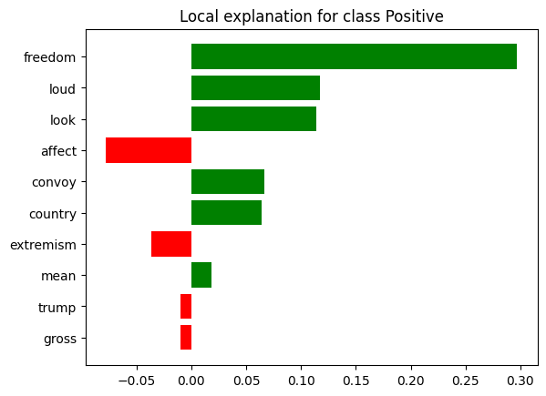

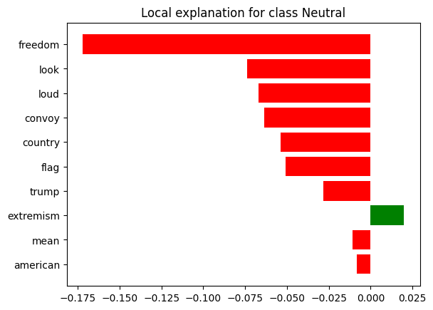

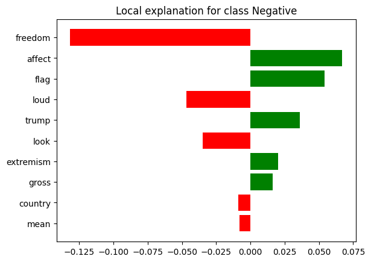

```python
import numpy as np
from lime import lime_text
from lime.lime_text import LimeTextExplainer

# Selecing  a sample from the test set for interpretation
sample_index = 50
if sample_index >= len(X_test):
    print(f"Error: Sample index {sample_index} is out of range.")
    exit()

text_to_interpret = " ".join([tokenizer.index_word.get(idx, '') for idx in X_test[sample_index] if idx != 0])

# Defining the LIME text explainer
explainer = LimeTextExplainer(class_names=['Positive', 'Neutral', 'Negative'])

# Defining a function to predict sentiment using the model
def predict_sentiment(texts):
    sequences = tokenizer.texts_to_sequences(texts)
    padded_sequences = pad_sequences(sequences, maxlen=max_sequence_length)
    predictions = model.predict(padded_sequences)
    return predictions

# Explaining the model's prediction for the sample text for each class
explanations = {}
for label in range(3):
    exp = explainer.explain_instance(text_to_interpret, predict_sentiment, num_features=10, labels=[label])
    explanations[label] = exp

    # Printing the explanation for each class
    print(f'\nExplanation for class {label}:')
    print(exp.as_list(label=label))

    # Plot the explanation
    fig = exp.as_pyplot_figure(label=label)
    fig.show()
```

- **Results**
- **Confusion Matrix Built?** : YES (BOTH TRAINING AND TESTING)
- **AUC plotted?** : YES (BOTH TRAINING AND TESTING)
- **Accuracy computed?** : YES (BOTH TRAINING AND TESTING)
- **Interpretability Implemented?** YES ( LOCAL)
- **CROSS VALIDATION :** YES (K-FOLD)
- **MODEL TUTING :** YES ( 3 ITERATION WITH RATIONAL FOR CHANGES MADE)
- MODEL TRAINING TIME : 100 minutes
- **Training Metrics :**
- Accuracy: 0.8626978521872793

  AUC Score: 0.9398722540143675
- F1-score (positive) : 0.91969971793622
- F1-Score (negative) : 0.7643099897875476
- **Testing Metrics :**
- Accuracy : 0.836318920535744
- Auc Score : 0.9124081612202396
- F1-score (positive) :0.903552731487032
- F1-Score (negative) :.7151409746145355

```python
!jupyter nbconvert --to html Unidirectional_RNN_using_Golve_Q_1.ipynb
```

```
[NbConvertApp] Converting notebook Unidirectional_RNN_using_Golve_Q_1.ipynb to html
[NbConvertApp] Writing 1150857 bytes to Unidirectional_RNN_using_Golve_Q_1.html
```